# Exploratory Data Analysis. Lab 5: Агрегация данных. Пакет dplyr

Сегодня мы будем учиться агрегации данных, которую можно осуществлять при помощи пакета `dplyr`. Для начала надо загрузить пакет `dplyr` и базу с данными о полетах самолетов, а также пакет `ggplot2`, с которым мы работали в прошлый раз.

Не забывайте при выполнении ДЗ познакомиться с гл. 4 Managing Data Frames with the dplyr package из книжки Exploratory Data Analysis with R.

Кроме того, обращайте внимание на то, что последние функции пакета dplyr можно найти в [dplyr cheatsheet](https://www.rstudio.com/wp-content/uploads/2015/02/data-wrangling-cheatsheet.pdf), также доступном в папке `minor2_2016/books`.

```r
library(dplyr)
library(nycflights13)
library(ggplot2)
```

Чтобы познакомиться с переменными в базе, введите `?flights`

```r
?nycflights13::flights
```

**Ваша очередь:** Что за информация содержится в следующих переменных: `origin`, `distance`, `tailnum`, `carrier`, `dest`?

Посмотрим, сколько наблюдений и переменных в базе, а также выведем 3 первые строчки.

```r
dim(flights)
```

```
## [1] 336776     19
```

```r
head(flights, n = 3)
```

```
## # A tibble: 3 x 19
##    year month   day dep_time sched_dep_time dep_delay arr_time
##   <int> <int> <int>    <int>          <int>     <dbl>    <int>
## 1  2013     1     1      517            515         2      830
## 2  2013     1     1      533            529         4      850
## 3  2013     1     1      542            540         2      923
## # ... with 12 more variables: sched_arr_time <int>, arr_delay <dbl>,
## #   carrier <chr>, flight <int>, tailnum <chr>, origin <chr>, dest <chr>,
## #   air_time <dbl>, distance <dbl>, hour <dbl>, minute <dbl>,
## #   time_hour <time>
```

Удалим все строки с NA (строки, в которых есть хотя бы одно пропущенное значение).

```r
flData = nycflights13::flights
flData = na.omit(flData)
```

Посмотрим, сколько осталось наблюдений и переменных в базе.

```r
dim(flData)
```

```
## [1] 327346     19
```

```r
head(flData, n = 3)
```

```
## # A tibble: 3 x 19
##    year month   day dep_time sched_dep_time dep_delay arr_time
##   <int> <int> <int>    <int>          <int>     <dbl>    <int>
## 1  2013     1     1      517            515         2      830
## 2  2013     1     1      533            529         4      850
## 3  2013     1     1      542            540         2      923
## # ... with 12 more variables: sched_arr_time <int>, arr_delay <dbl>,
## #   carrier <chr>, flight <int>, tailnum <chr>, origin <chr>, dest <chr>,
## #   air_time <dbl>, distance <dbl>, hour <dbl>, minute <dbl>,
## #   time_hour <time>
```

**Ваша очередь:**

Давайте вспомним, как работает ggplot.

1. Нарисуйте boxplot (ящик с усами), в котором по оси X будут аэропорты Нью-Йорка, из которых вылетают самолеты, а по оси Y - дистанция.
2. Нарисуйте гистограмму по переменной `hour`. Посмотрите, как работают параметры *coord_flip* и *coord_polar*. Также вспомните, как менять цвет у графика.
3. Нарисуйте bar chart по переменной `carrier`. Закрасьте столбцы таким образом, чтобы можно было видеть, сколько перелетов для каждого перевозчика относятся к каждому из трех аэропортов, работающих в Нью-Йорке.

Переходим к исследованию более сложных зависимостей (и более сложным условиям).

Сначала напоминание про основную пунктуацию:

- < - меньше
- == - равно
- != - не равно
- | - или (выполнено хотя бы одно из условий)
- & - и (выполнены оба условия)
- ! - не
- : - интервал (a:b - все от a до b)

Переходим к основным функциям dplyr.

# filter

Допустим, нас интересуют только полеты в летние месяцы

```r
#?filter
flData = filter(flData, month == 6 | month == 7 | month == 8)
```

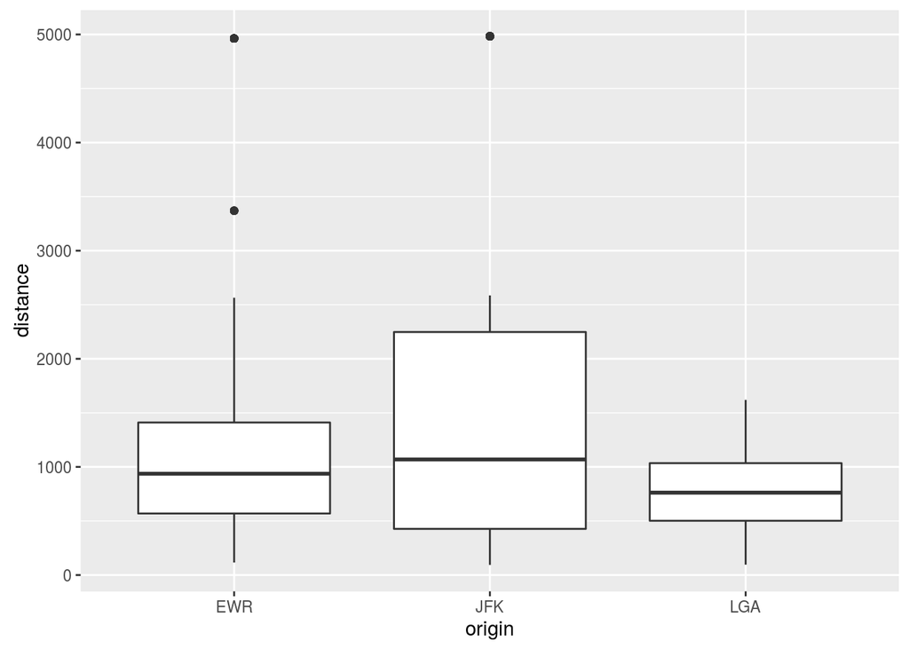

```r
ggplot(data = flData) + geom_boxplot(aes(x = origin, y = distance))
```

Теперь отберем только те рейсы, в которых пункт назначения Майами (MIA - Miami International Airport)

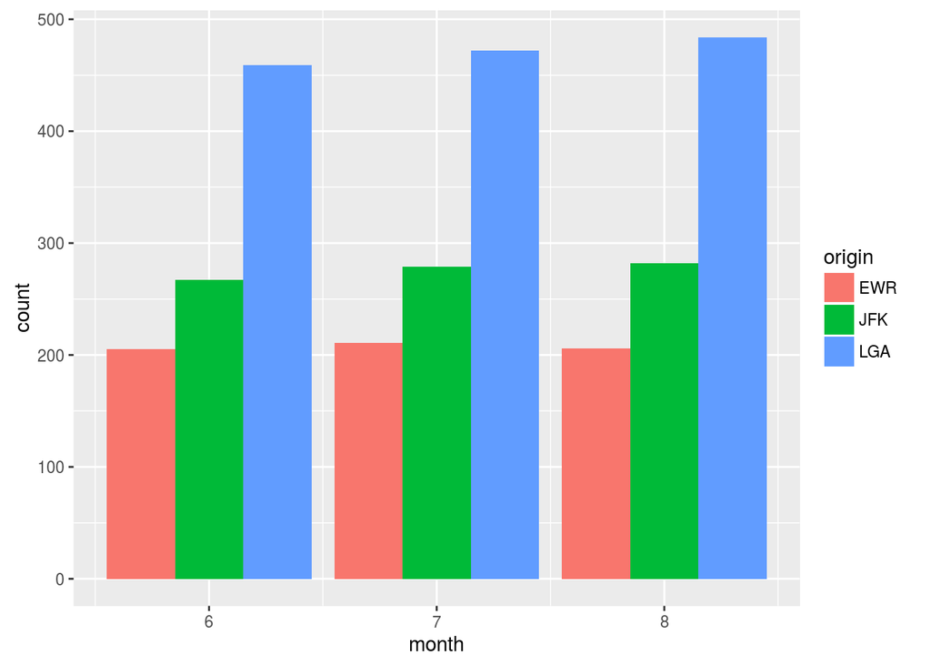

```r
flData = filter(flData, dest == "MIA")
ggplot(data = flData) + geom_bar(aes(x = month, fill = origin), position = "dodge")
```

# arrange

Упорядочим рейсы по времени вылета

```r
#?arrange
flData = arrange(flData, year, month, day)
head(flData)
```

```
## # A tibble: 6 x 19
##    year month   day dep_time sched_dep_time dep_delay arr_time
##   <int> <int> <int>    <int>          <int>     <dbl>    <int>
## 1  2013     6     1      539            540        -1      832
## 2  2013     6     1      555            605       -10      838
## 3  2013     6     1      558            600        -2      832
## 4  2013     6     1      609            615        -6      852
## 5  2013     6     1      656            700        -4      939
## 6  2013     6     1      718            725        -7     1016
## # ... with 12 more variables: sched_arr_time <int>, arr_delay <dbl>,
## #   carrier <chr>, flight <int>, tailnum <chr>, origin <chr>, dest <chr>,
## #   air_time <dbl>, distance <dbl>, hour <dbl>, minute <dbl>,
## #   time_hour <time>
```

```r
flData = arrange(flData, desc(dep_delay))
head(flData)
```

```
## # A tibble: 6 x 19
##    year month   day dep_time sched_dep_time dep_delay arr_time
##   <int> <int> <int>    <int>          <int>     <dbl>    <int>
## 1  2013     7    21     1555            615       580     1955
## 2  2013     6    30     1842           1125       437     2229
## 3  2013     8    28     2315           1559       436      158
## 4  2013     8     5     1917           1240       397     2226
## 5  2013     7    28      105           1925       340      401
## 6  2013     7    22     2119           1559       320      116
## # ... with 12 more variables: sched_arr_time <int>, arr_delay <dbl>,
## #   carrier <chr>, flight <int>, tailnum <chr>, origin <chr>, dest <chr>,
## #   air_time <dbl>, distance <dbl>, hour <dbl>, minute <dbl>,
## #   time_hour <time>
```

# select

Отберем для дальнейшего анализа только данные о номере рейса и задержках, удалим из рассмотрения переменную `arr_time`

```r
#?select
str(flData)
```

```
## Classes 'tbl_df', 'tbl' and 'data.frame':    2865 obs. of  19 variables:
##  $ year          : int  2013 2013 2013 2013 2013 2013 2013 2013 2013 2013 ...
##  $ month         : int  7 6 8 8 7 7 7 6 7 6 ...
##  $ day           : int  21 30 28 5 28 22 14 24 12 18 ...
##  $ dep_time      : int  1555 1842 2315 1917 105 2119 1420 2111 2002 1951 ...
##  $ sched_dep_time: int  615 1125 1559 1240 1925 1559 905 1559 1455 1455 ...
##  $ dep_delay     : num  580 437 436 397 340 320 315 312 307 296 ...
##  $ arr_time      : int  1955 2229 158 2226 401 116 1709 28 2308 2309 ...
##  $ sched_arr_time: int  910 1440 1919 1545 2243 1922 1225 1925 1830 1830 ...
##  $ arr_delay     : num  645 469 399 401 318 354 284 303 278 279 ...
##  $ carrier       : chr  "AA" "AA" "DL" "UA" ...
##  $ flight        : int  1895 2099 1373 1186 2139 1373 874 1373 779 779 ...
##  $ tailnum       : chr  "N3EMAA" "N3BTAA" "N3763D" "N12109" ...
##  $ origin        : chr  "EWR" "LGA" "JFK" "EWR" ...
##  $ dest          : chr  "MIA" "MIA" "MIA" "MIA" ...
##  $ air_time      : num  177 202 134 134 150 138 135 143 153 164 ...
##  $ distance      : num  1085 1096 1089 1085 1096 ...
##  $ hour          : num  6 11 15 12 19 15 9 15 14 14 ...
##  $ minute        : num  15 25 59 40 25 59 5 59 55 55 ...
##  $ time_hour     : POSIXct, format: "2013-07-21 06:00:00" "2013-06-30 11:00:00" ...
##  - attr(*, "na.action")=Class 'omit'  Named int [1:9430] 472 478 616 644 726 734 755 839 840 841 ...
##   .. ..- attr(*, "names")= chr [1:9430] "472" "478" "616" "644" ...
```

```r
flData = dplyr::select(flData, tailnum, dep_delay:arr_delay)
flData = dplyr::select(flData, -arr_time)
str(flData)
```

```
## Classes 'tbl_df', 'tbl' and 'data.frame':    2865 obs. of  4 variables:
##  $ tailnum       : chr  "N3EMAA" "N3BTAA" "N3763D" "N12109" ...
##  $ dep_delay     : num  580 437 436 397 340 320 315 312 307 296 ...
##  $ sched_arr_time: int  910 1440 1919 1545 2243 1922 1225 1925 1830 1830 ...
##  $ arr_delay     : num  645 469 399 401 318 354 284 303 278 279 ...
##  - attr(*, "na.action")=Class 'omit'  Named int [1:9430] 472 478 616 644 726 734 755 839 840 841 ...
##   .. ..- attr(*, "names")= chr [1:9430] "472" "478" "616" "644" ...
```

# rename

Переименуем переменную `tailnum` для единообразия в `tail_num`

```r
flData = rename(flData, tail_num = tailnum)
```

# summarise & mutate

**Ваша очередь:** В чем отличия функций `summarise()` и `mutate()`?

```r
?summarise
```

```
## Help on topic 'summarise' was found in the following packages:
##
##   Package               Library
##   dplyr                 /usr/lib/R/site-library
##   plyr                  /usr/lib/R/library
##
##
## Using the first match ...
```

```r
?mutate
```

```
## Help on topic 'mutate' was found in the following packages:
##
##   Package               Library
##   dplyr                 /usr/lib/R/site-library
##   plyr                  /usr/lib/R/library
##
##
## Using the first match ...
```

```r
flData = mutate(flData, dep_arr_dif = arr_delay - dep_delay)
summarise(flData, mean_dif = mean(dep_arr_dif))
```

```
## # A tibble: 1 x 1
##    mean_dif
##       <dbl>
## 1 -7.719372
```

**Ваша очередь:** Что означает полученное число?

# group_by

Если нам нужно значение не для всей выборки, а для каждого из рейсов, то мы сначала группируем по номеру рейса, а затем вычисляем нужную характеристику

```r
flData = group_by(flData, tail_num)
tail_dif = dplyr::summarise(flData, median_dif = median(dep_arr_dif))
tail_dif
```

```
## # A tibble: 790 x 2
##    tail_num median_dif
##       <chr>      <dbl>
## 1    N12109      -11.0
## 2    N12114      -12.0
## 3    N12116      -28.0
## 4    N12125       12.0
## 5    N12216       -1.0
## 6    N12218       13.5
## 7    N12238        0.0
## 8    N13110      -20.0
## 9    N13113        1.0
## 10   N13138        0.0
## # ... with 780 more rows
```

# join

Объединение нескольких датасетов в один по одной из переменных

```r
?join
```

```
## Help on topic 'join' was found in the following packages:
##
##   Package               Library
##   dplyr                 /usr/lib/R/site-library
##   plyr                  /usr/lib/R/library
##
##
## Using the first match ...
```

В чем разница `inner_join()` и `left_join()`?

```r
flData = inner_join(x = flData, y = tail_dif, by = "tail_num")
str(flData)
```

```
## Classes 'grouped_df', 'tbl_df', 'tbl' and 'data.frame':  2865 obs. of  6 variables:
##  $ tail_num      : chr  "N3EMAA" "N3BTAA" "N3763D" "N12109" ...
##  $ dep_delay     : num  580 437 436 397 340 320 315 312 307 296 ...
##  $ sched_arr_time: int  910 1440 1919 1545 2243 1922 1225 1925 1830 1830 ...
##  $ arr_delay     : num  645 469 399 401 318 354 284 303 278 279 ...
##  $ dep_arr_dif   : num  65 32 -37 4 -22 34 -31 -9 -29 -17 ...
##  $ median_dif    : num  2 -12 -37 -11 -18 -3.5 -27 -22 -6 -14.5 ...
##  - attr(*, "vars")=List of 1
##   ..$ : symbol tail_num
```

```r
flData = arrange(flData, median_dif)
flData
```

```
## Source: local data frame [2,865 x 6]
## Groups: tail_num [790]
##
##    tail_num dep_delay sched_arr_time arr_delay dep_arr_dif median_dif
##       <chr>     <dbl>          <int>     <dbl>       <dbl>      <dbl>
## 1    N3AKAA        -9           1305       -57         -48        -48
## 2    N374AA         3           1835       -43         -46        -46
## 3    N25705        -2           2332       -46         -44        -44
## 4    N393DA        26           1919       -16         -42        -42
## 5    N385DN         2           1919       -38         -40        -40
## 6    N6704Z       107           2141        68         -39        -39
## 7    N957DL        69           1558        23         -46        -39
## 8    N342AA        30           1835        -9         -39        -39
## 9    N957DL        13           1558       -19         -32        -39
## 10   N3KLAA        30           1430        -6         -36        -38
## # ... with 2,855 more rows
```

# Два основных способа работы с `dplyr`

Вернемся к первоначальному датасету

```r
flights = nycflights13::flights
flights = na.omit(flights)
```

1. Мы можем выполнять операции пошагово (step-by-step), сохраняя промежуточные результаты

```r
a1 = group_by(flights, year, month, day)
a2 = select(a1, arr_delay, dep_delay)
a3 = summarise(a2,
  arr = mean(arr_delay, na.rm = TRUE),
  dep = mean(dep_delay, na.rm = TRUE))
a4 = filter(a3, arr > 30 | dep > 30)
```

**Ваша очередь:** Какие данные, как вы думаете, остались в `a4`?

2. Либо можем работать с помощью pipes (%>%)

```r
delays = flights %>%
  group_by(year, month, day) %>%
  select(arr_delay, dep_delay) %>%
  summarise(
    arr = mean(arr_delay, na.rm = TRUE),
    dep = mean(dep_delay, na.rm = TRUE)
  ) %>%
  filter(arr > 30 | dep > 30)
```

## Ваша очередь

Загрузить базу по колледжам

```r
colleges = ISLR::College
?ISLR::College
```

Оставить в базе только вузы с Graduation Rate меньше 50%

```r
colleges = filter(colleges, ...)
```

Создать 2 новые колонки. Первая – отношение принятых (одобренных) заявлений на поступление к количеству полученных заявлений. Вторая – отношение количества поступивших студентов к количеству принятых заявлений

```r
colleges = mutate(colleges, ...)
```

Оставить только две новые колонки, созданные на предыдущем шаге, и колонку, соответствующую типу вуза (является ли вуз частным или государственным).

```r
colleges = dplyr::select(colleges, ...)
```

Построить графики для сравнения доли принятых заявлений между типами вузов и сравнения доли поступивших студентов между типами вузов

```r
ggplot(data = colleges) + ...
```

Сгрупировать базу по типу вуза (частный или государственный), посчитать средние значения по оставшимся двум колонкам.

```r
colleges %>% group_by(...) %>% dplyr::summarize(...)
```

Загрузите базу заново

```r
colleges = ISLR::College
```

Постройте график, чтобы сравнить каких колледжей в базе больше, частных или государственных

```r
ggplot(data = colleges) + ...
```

Создайте новую колонку, отражающую, приходится ли на одного преподавателя больше 13 студентов или нет

```r
colleges = mutate(colleges, ...)
```

Постройте график, отражающий взаимосвязь между типом колледжа и тем, приходится ли в нем на одного преподавателя больше 13 студентов или нет

```r
ggplot(data = colleges) + ...
```

Постройте график, отражающий взаимосвязь между затратами на обучение одного студента и количеством поданных заявлений в колледж

```r
ggplot(data = colleges) + ...
```

Посчитайте среднее количество fulltime undergraduates и parttime undergraduates в частных и государственных колледжах

```r
colleges %>% group_by(...) %>% dplyr::summarize(...)
```

Выберите колледжи, в которых суммарные затраты (personal, books, room) не превышают 6000. Каких колледжей в этой категории больше?

Сформулируйте свой вопрос по рассматриваемой базе. Выполните вычисления / постройте график для ответа на него.